# Algorytmy danych geoprzestrzennych

Operacje nakładania warstw wektorowych

Krzysztof Dyba

## Nakładanie warstw wektorowych

Nakładanie warstw wektorowych (*vector overlay*) to podstawowy zbiór operacji wykorzystywany w systemach informacji geograficznej do łączenia wektorowych zbiorów danych w celu analizy i zrozumienia relacji przestrzennych.

Do analizy mogą zostać wykorzystane różne typy geometrii reprezentujące przykładowo drzewa, granice, drogi czy budynki.

Proces nakładania łączy geometrię i atrybuty warstw wejściowych, umożliwiając sprawdzenie, w jaki sposób cechy z różnych warstw wpływają na siebie w przestrzeni.

## Zastosowania

- Analizy środowiskowe, np. analiza związku pomiędzy siedliskami gatunków a klasami pokrycia terenu
- Zarządzanie kryzysowe, np. analiza obszarów zagrożonych powodzią uwzględniając dane o gęstości zaludnienia
- Planowanie przestrzenne, np. określanie odpowiednich lokalizacji pod zabudowę uwzględniając obszary chronione i aktualną infrastrukturę
- Analiza rynku, np. powiązanie lokalizacji klientów z danymi demograficznymi w celu ukierunkowania sprzedaży do określonej grupy

## Przykład

Wyodrębnienie tylko tych rzek, które przepływają przez wielkopolskę.

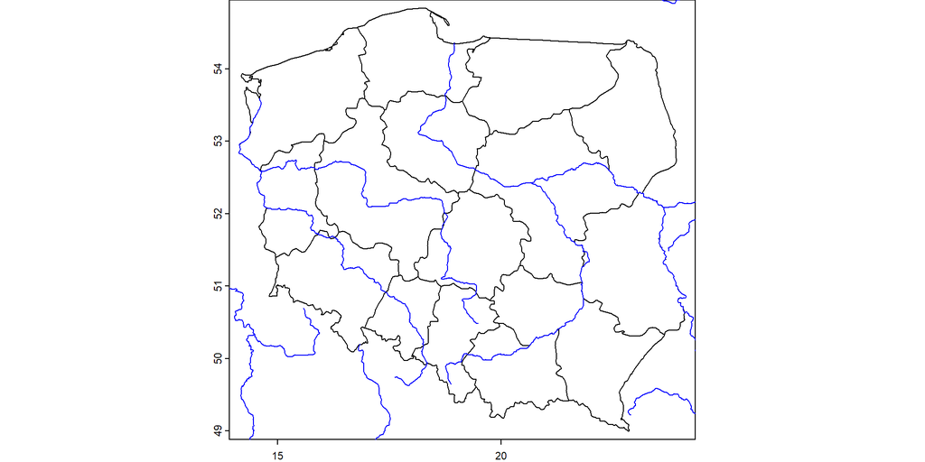

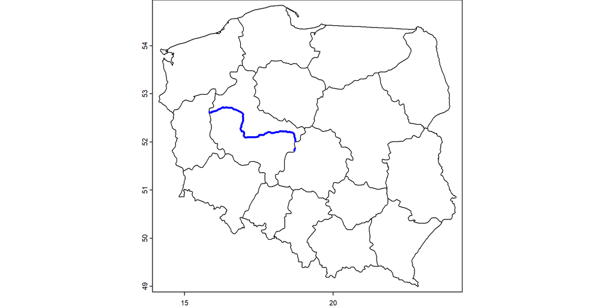

```
intersect(admin[admin$woj == "Wielkopolskie"], rzeki)
```

## Algorytmy

- Usuwanie (*Erase*, *Difference*)
- Przecięcie (*Intersect*) / Koniunkcja
- Złączenie (*Union*) / Alternatywa
- Różnica symetryczna (*Symmetrical difference*) / Alternatywa rozłączna
- Przykrycie (*Update*, *Cover*)
- Docinanie (*Clip*)

## Usuwanie

Wynik obejmuje tylko te obiekty z jednej warstwy, które nie nakładają się na drugą warstwę.

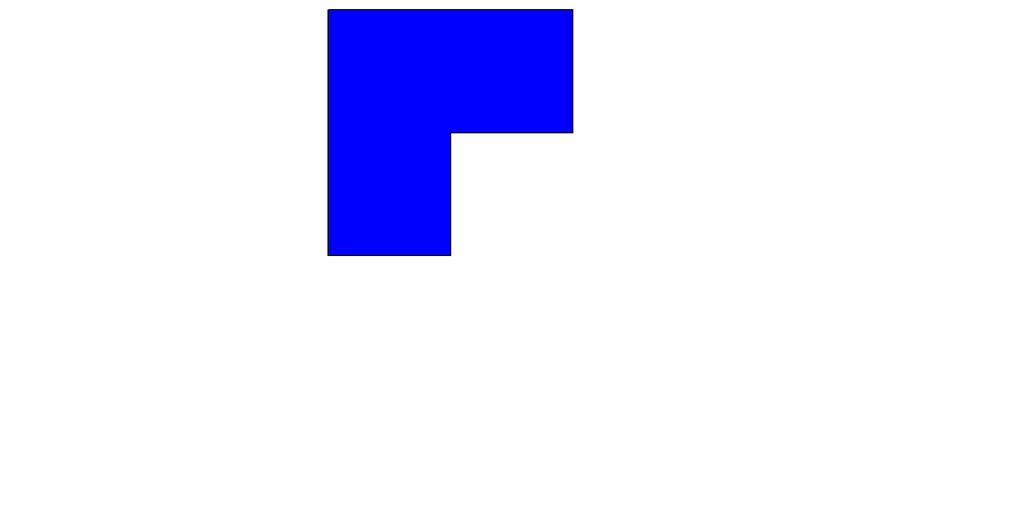

```r
p1 = vect("POLYGON ((0 0, 10 0, 10 10, 0 10, 0 0))")
p2 = vect("POLYGON ((5 5, 5 -5, 15 -5, 15 5, 5 5))")
erase(p1, p2)
```

## Przecięcie

Wynik obejmuje tylko te obiekty, które nakładają się na obu warstwach wejściowych.

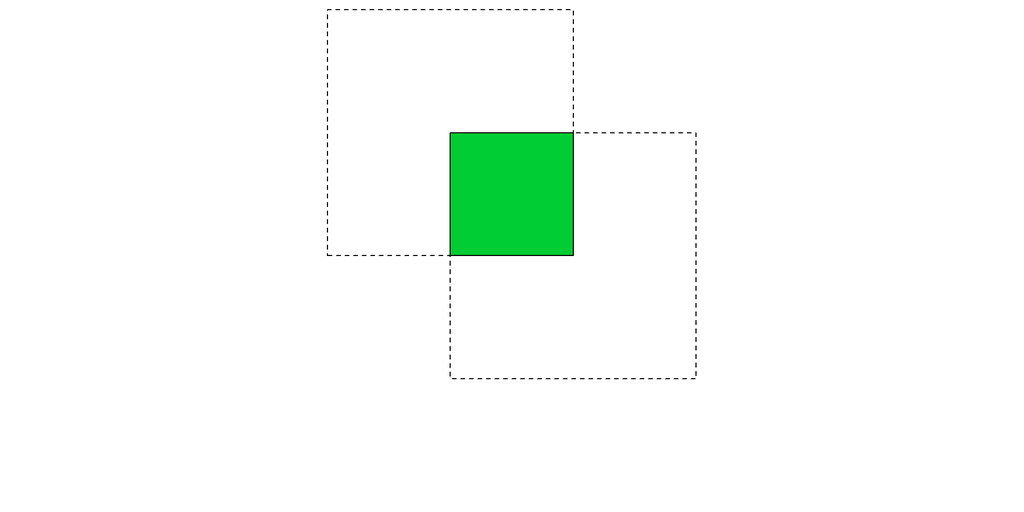

```r
p1 = vect("POLYGON ((0 0, 10 0, 10 10, 0 10, 0 0))")
p2 = vect("POLYGON ((5 5, 5 -5, 15 -5, 15 5, 5 5))")
intersect(p1, p2)
```

**Przykład:** Przecięcie warstwy typów gleby z warstwą działek pokaże typ gleby w obrębie każdej działki.

## Złączenie

Wynik obejmuje wszystkie obiekty z obu warstw wejściowych, w tym nakładające się obszary.

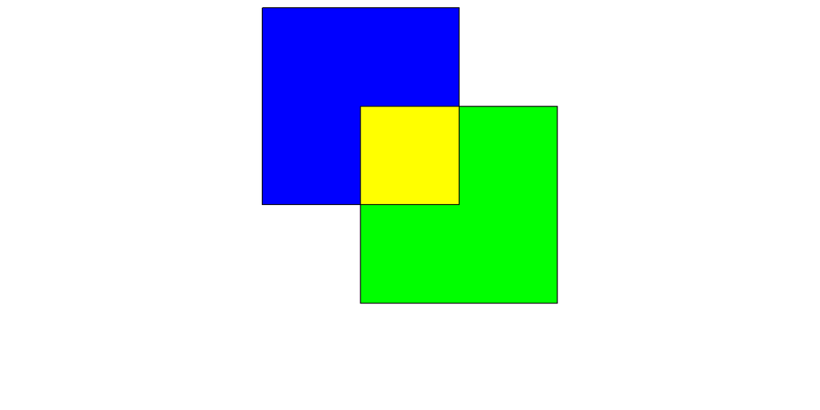

```r
p1 = vect("POLYGON ((0 0, 10 0, 10 10, 0 10, 0 0))")
p2 = vect("POLYGON ((5 5, 5 -5, 15 -5, 15 5, 5 5))")
union(p1, p2)
```

**Przykład:** Złączenie warstwy obszarów zagrożonych powodziami i warstwy obszarów zagrożonych osuwiskami, zwróci obszary zagrożone powodzią, osuwiskami oraz jednocześnie powodzią i osuwiskami.

## Różnica symetryczna

Wynik obejmuje obszary, w których warstwy wejściowe nie zachodzą na siebie, tj. wyklucza obszary przecięcia.

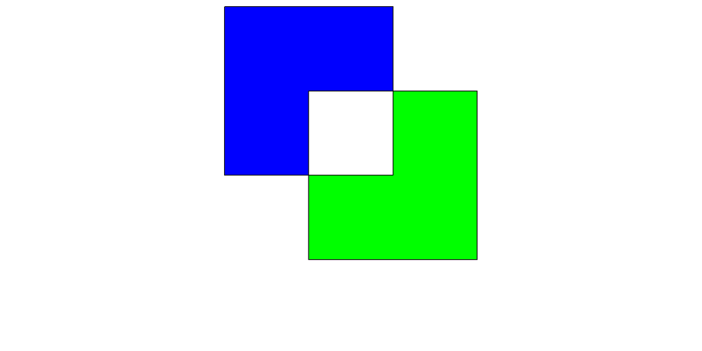

```r
p1 = vect("POLYGON ((0 0, 10 0, 10 10, 0 10, 0 0))")
p2 = vect("POLYGON ((5 5, 5 -5, 15 -5, 15 5, 5 5))")
symdif(p1, p2)
```

**Przykład:** Wykrywanie zmian pokrycia terenu w czasie.

## Przykrycie

Wynikiem jest nowa warstwa zawierająca zaktualizowane obiekty pierwszej warstwy wejściowej na podstawie drugiej.

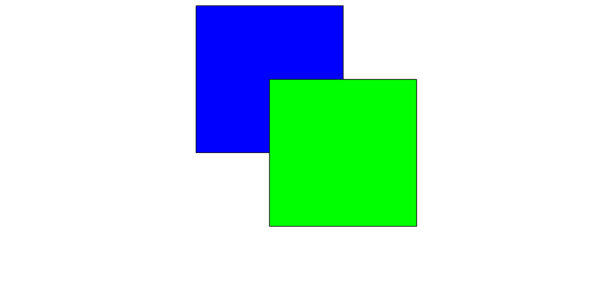

```r
p1 = vect("POLYGON ((0 0, 10 0, 10 10, 0 10, 0 0))")
p2 = vect("POLYGON ((5 5, 5 -5, 15 -5, 15 5, 5 5))")
cover(p1, p2)
```

**Przykład:** Aktualizacja przebiegu granic działek ewidencyjnych.

## Docinanie

Docinanie jest podobną operacją do przecięcia, z tą różnicą, że atrybuty pochodzące z drugiej warstwy nie są kopiowane.

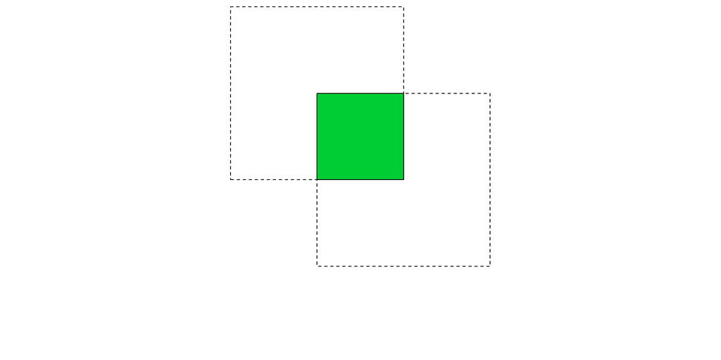

```r
p1 = vect("POLYGON ((0 0, 10 0, 10 10, 0 10, 0 0))")
p2 = vect("POLYGON ((5 5, 5 -5, 15 -5, 15 5, 5 5))")
crop(p1, p2)
```

**Przykład:** Wyodrębnienie dróg, które znajdują się w granicach miasta.

## Zwracane typy geometrii

Wyjściowy typ geometrii przy docinaniu może być identyczny lub niższy.

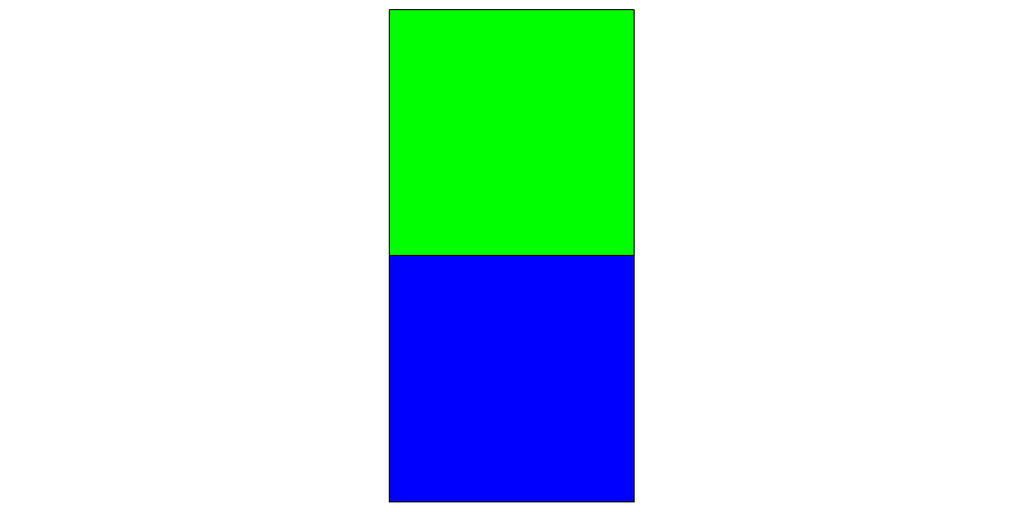

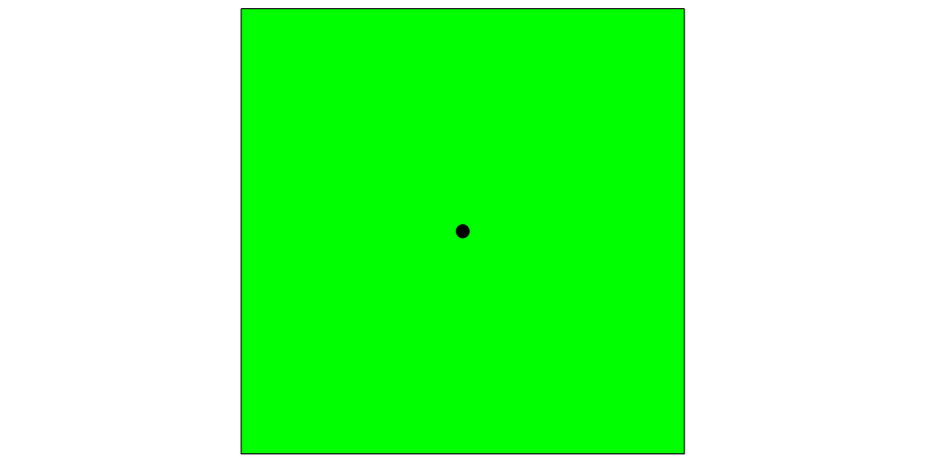

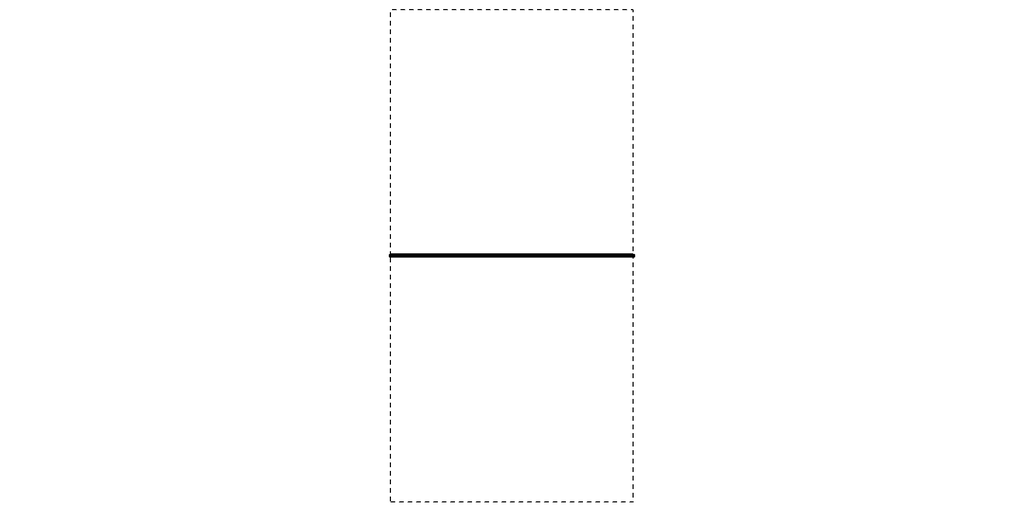

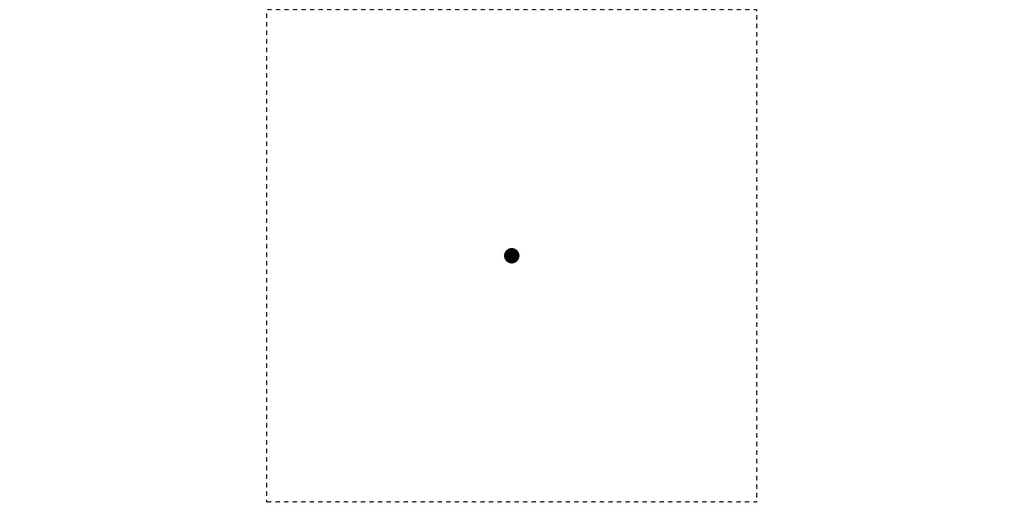

## Srebrne poligony

## Srebrne poligony

Pojęcie srebrnego poligonu (*sliver polygon*) odnosi się do małego, wąskiego i często niezamierzonego wielokąta, który powstaje w wyniku przetwarzania danych przestrzennych, np. podczas operacji przecięcia, łączenia lub przycinania warstw wektorowych.

Najczęściej powstają na skutek niedopasowanych granic lub ograniczonej precyzji zapisu danych, co powoduje niewielkie przerwy pomiędzy obiektami.

## Przykład

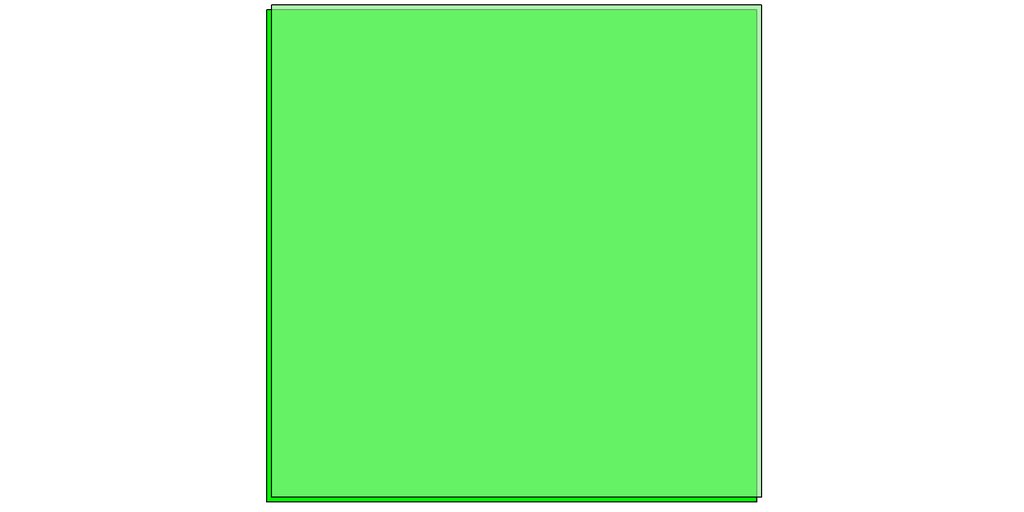

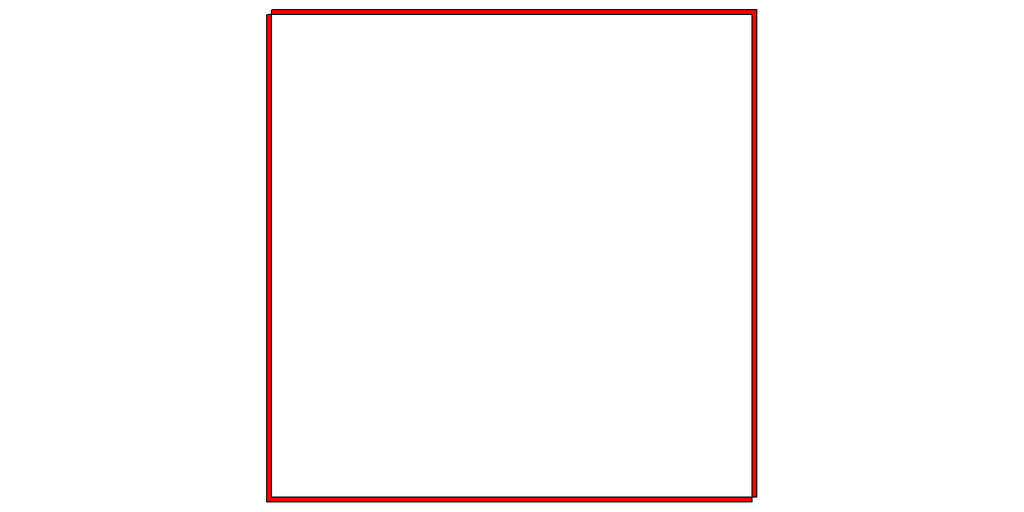

```r
p1 = vect("POLYGON ((0 0, 10 0, 10 10, 0 10, 0 0))")
p2 = vect("POLYGON ((0.1 0.1, 10.1 0.1, 10.1 10.1, 0.1 10.1, 0.1 0.1))")
symdif(p1, p2)
```

## Konsekwencje

- Błędne obliczenia powierzchni i obwodów
- Błędy topologiczne
- Negatywne efekty wizualne

## Rozwiązania

1. Kontrola i czyszczenie danych wejściowych
2. Generalizacja danych wejściowych (uproszczenie geometrii)
3. Ustawienia wartości tolerancji podczas operacji
4. Post-processing (usuwanie poligonów na podstawie wartości progowej)